# R Notebook

```r
library(tidyverse)
library(glue)
```

#天体リスト

- 最小限のリストにしておく
- 特定の天体でのみ必要な情報は元のリストをたどる
- そのために識別の為の名前は編集しない
- 処理やりなおしが自動でできるようにしておく
- いらない情報は早めに消す
- Typeはそのままにしておいて、検索時にマージ RNのみ、見つけ次第スクリプトで編集
- ターゲット名はM,C,NGC,ICナンバーから自動生成するようにする
  - Mx,nickname
  - Mx
  - NGC/ICxxxx,Cx,nickname
  - NGC/ICxxxx,nickname
  - NGC/ICxxxx
  - otherxxx

## OpenNGC

https://github.com/mattiaverga/OpenNGC + 座標はNED, 投球はSIMBAD + csv,ods + NGC/IC以外の天体が20ほど

### NGC_guide.txt

カタログ名/ID/subIDに分離して整理 + Name: Object name composed by catalog + number NGC: New General Catalogue IC: Index Catalogue

統計をみて消す/マージするタイプを整理 - Type: Object type

残す + RA: Right Ascension in J2000 Epoch (HH:MM:SS.SS) + Dec: Declination in J2000 Epoch (+/-DD:MM:SS.SS) + Const: Constellation where the object is located

- MajAx: Major axis, expressed in arcmin

必要ならあとで参照 Bがあるものが多いが、Vのみも100ほどある - MinAx: Minor axis, expressed in arcmin - PosAng: Major axis position angle (North Eastwards) - B-Mag: Apparent total magnitude in B filter - V-Mag: Apparent total magnitude in V filter - J-Mag: Apparent total magnitude in J filter - H-Mag: Apparent total magnitude in H filter - K-Mag: Apparent total magnitude in K filter

銀河用 必要ならあとで参照 - SurfBr (only Galaxies): Mean surface brigthness within 25 mag isophot (B-band), expressed in mag/arcsec2 - Hubble (only Galaxies): Morphological type (for galaxies)

PN用 必要ならあとで参照 - Cstar U-Mag (only Planetary Nebulae): Apparent magnitude of central star in U filter - Cstar B-Mag (only Planetary Nebulae): Apparent magnitude of central star in B filter - Cstar V-Mag (only Planetary Nebulae): Apparent magnitude of central star in V filter - Cstar Names (only Planetary Nebulae): central star identifications

整理する Dupをのぞいて必要か確認 - M: cross reference Messier number - NGC: other NGC identification, if the object is listed twice in the catalog - IC: cross reference IC number, if the object is also listed with that identification

どんなカタログが参照されているか確認 - Identifiers: cross reference with other catalogs + C以外のカタログを削除して、Cは別カラムに移動 - Common names: Common names of the object if any + 後から追加してもいいかも - NED Notes: notes about object exported from NED + データの出所や星の分類・他の星雲/星団/系外銀河の一部かどうかなどいらない - OpenNGC Notes: notes about the object data from OpenNGC catalog + C14(h-χ)が2天体 -> 別途編集 + 他はあまり重要なものはない-> 削除

```r
dat0 <- read_delim("../OpenNGC-master/NGC.csv", ";",
                  col_types = cols(RA = col_character()),
                  guess_max = 10000)
dat0a <- read_delim("../OpenNGC-master/addendum/addendum.csv", ";",
                  col_types = cols(RA = col_character()),
                  guess_max = 10000)
dat0 <- bind_rows(dat0, dat0a)
#dat0 <- dat0 %>% select(1:5, 6, 19:21, 23:26)
dat0 <- dat0 %>% select(1:5, 19:21, 23:24)
dat0 <- rename(dat0, CommonNames = "Common names")

dat1 <- dat0
dat1 <- dat1 %>% filter(Type != "*")
dat1 <- dat1 %>% filter(!is.na(M) | Type != "**")
dat1 <- dat1 %>% filter(Type != "Dup")
dat1 <- dat1 %>% filter(!is.na(M) | Type != "Other")
dat1 <- dat1 %>% filter(!is.na(CommonNames) | Type != "*Ass")
dat1 <- dat1 %>% filter(Type != "Nova")
dat1 <- dat1 %>% filter(Type != "NonEx")
#filter(dat1, !is.na(M)) %>% View()
#dat2 <- filter(dat1, Type == "*Ass")
dat1 <- dat1 %>%
  mutate(Type = recode(Type,
    "GCl" = "GC",
    "OCl" = "OC",
    "**" = "A",
    "*Ass" = "A",
    "DrkN" = "DN",
    "RfN" = "RN",
    "EmN" = "EN",
    "GPair" = "Gp",
    "GTrpl" = "Gt",
    "GGroup" = "Gg"))

remove_catalogs <- function(id) {
 ccc <- id
 if(!is.na(id)) {
   ccc <- str_split(ccc, ",")[[1]]

   patterns <- c("2MASX", "IRAS", "MCG", "PGC", "UGC",
                 "LEDA", "2MASS", "ESO ", "ESO-LV ",
                 "6dF ", "ESOLV", "SDSS",
                 "LBN ", "MWSC ", "TYC ", "BD", "HIP ", "HD ",
                 "IDS ", "WDS ", "UCAC", "SAO ",
                 "PK ", "PN G")
  # ccc <- ccc[-na.omit(charmatch(patterns, ccc))] #最後しかマッチできない

   for(pattern in patterns) {
     ccc <- ccc[!str_detect(ccc, pattern)]
   }

   ccc <- paste(ccc, collapse = ",")
   if(ccc == "") { ccc = NA_character_ }
 }
 ccc
}

#不要なカタログ名を除去
dat2 <- dat1 %>%
 mutate(Identifiers = map_chr(Identifiers, remove_catalogs))

#Caldwel天体の番号を抽出/修正
dat3 <- dat2 %>%
  transmute(Name, Type, RA, Dec, Const, M, NGC, IC,
            C = as.integer(parse_number(Identifiers)),
            Identifiers, CommonNames) %>%
  mutate(CommonNames = if_else(str_sub(Name, 1, 2) == "C0" & !is.na(Identifiers),
                               as.character(glue("{CommonNames},{Identifiers}")),
                               CommonNames)) %>%
  mutate(C = if_else(str_sub(Name, 1, 2) == "C0", as.integer(parse_number(Name)), C)) %>%
  mutate(CommonNames = if_else(!is.na(C) & C == 64, "Tau CMa", CommonNames)) %>%
  select(-Identifiers)
```

```
1 parsing failure.
 row col expected   actual
5651  -- a number Fornax A
```

```r
#Messier天体を修正
dat4 <- dat3 %>%
  mutate(M = as.integer(parse_number(M))) %>%
  mutate(CommonNames = if_else(Name == "NGC5866", "M102?", CommonNames)) %>%
  mutate(M = if_else(Name == "NGC5866", as.integer(102), M)) %>%
  mutate(Type = if_else(!is.na(M) & M == 73, "A", Type))

dat5 <- dat4 %>%
  mutate(IC = if_else(str_sub(Name, 1, 2) == "IC",
                      as.integer(parse_number(Name)), NA_integer_)) %>%
  mutate(NGC = if_else(str_sub(Name, 1, 3) == "NGC",
                       as.integer(parse_number(Name)), NA_integer_))

#filter(dat5, !is.na(M)) %>% arrange(M) %>% View # NGC5866をM102として110個
#filter(dat5, !is.na(C)) %>% arrange(C) %>% View #109個 初版の間違いは修正済みなのを確認

filter(dat5, !is.na(M) | !is.na(C) | !is.na(CommonNames)) %>%
  arrange(M, C, NGC, IC) %>% View() #この273個が最初のターゲットリストか 重複/細分あるけど...
saveRDS(dat5, file = "../object.rds")
```

あとは書籍で出てきた天体を追加 Shiny spread sheetをテスト？

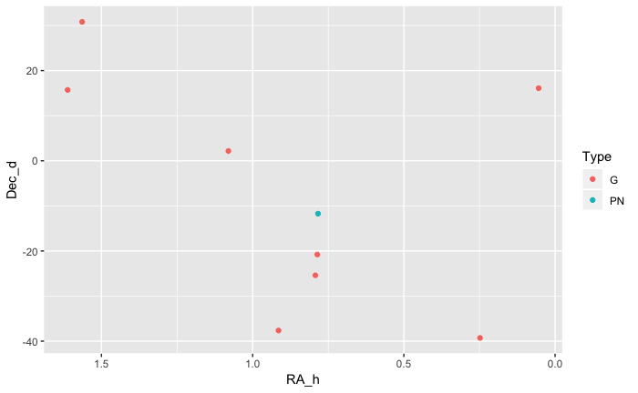

```r
dat0 <- readRDS("../object.rds")
dat1 <- dat0 %>%
  filter(!is.na(M) | !is.na(C) | !is.na(CommonNames))

library(astroFns)
dat1 <- dat1 %>%
  mutate(RA_h = hms2rad(RA) / 2 / pi * 24.0,
         Dec_d = dms2rad(Dec) / 2 / pi * 360.0)
dat1 <- dat1 %>%
  mutate(Type = recode(Type,
    "GCl" = "GC",
    "OCl" = "OC",
    "A" = "OC",
    "EN" = "HII",
    "Neb" = "HII",
    "Cl+N" = "HII",
    "RN" = "OC",
    "Gp" = "G",
    "Gt" = "G",
    "Gg" = "G"))
dat2 <- dat1 %>%
  filter(RA_h >= 24
         | RA_h <= 2) %>%
  filter(between(Dec_d, -45, 35))
ggplot(dat2) + geom_jitter(aes(RA_h, Dec_d, color = Type)) +
  scale_x_reverse()
```

```r
View(dat2)
```

RA/DECでプロット 銀経/銀緯でプロット visibilityをプロット

銀河が多い

[figure not shown]

```r
ggplot(dat1) + geom_bar(aes(Type, fill = Type), ) +
  theme(legend.position = "top") + coord_cartesian(ylim = c(0, 700))
```

addenment.csvとNGC.csvをマージして編集 + 削除 *: Star + 削除 **: Double star M40残す + 削除 *Ass: Association of stars 60個 M24, MW/M33/LMCのstar cloud, asterismなど… 名前ありは残す + Cl+N: Star cluster + Nebula 66個 M42, NGC2264 + DN DrkN: Dark Nebula addendumに2個 + 削除 Dup: Duplicated object (see NGC or IC columns to find the master object) + HII EmN: Emission Nebula 8個 全部LMCの天体 + G G: Galaxy サブIDで整理 + GC GCl: Globular Cluster 205個 + Gg GGroup: Group of galaxies 16個 サブIDでそれぞれの数を確認 -> サブIDつき以外は消してもOK? + Gp GPair: Galaxy Pair 212個 + Gt GTrpl: Galaxy Triplet 23個 + HII HII: HII Ionized region82個 馬頭星雲など+ LMCの天体 + Neb: Nebula 93個 M,Cが結構入ってる HIIもRNも含む感じ？ + HII IC405(Flaming Star), IC2159(Monkeyの一部), IC4703(M16), IC4955(IC4954とペア) + RN IC4604(rho Oph), NGC1435(Melope), NGC7023(Iris), NGC5134(NGC7129), M8, M20 + EN NGC6164-65 + OC M16 + 削除 Nova: Nova star IC4544, 4816, 4850 Nova 1900以前の写真乾板で見つかった天体 + 削除 NonEx: Nonexistent object 14個

- OC OCl: Open Cluster 650個 LMC/SMCのが結構ある
- PN PN: Planetary Nebula PN 129個
- RN RfN: Reflection Nebula 38個 名前ありのが5個
- SNR SNR: Supernova remnant 11個 カニ星雲, 網状星雲以外は厳しそう IC443(GemA), NGC6334くらいか？ Dorにあと一つ
- Other Other: Other classification (see object notes).. 430個
  - 色々なのが混ざってるので再分類
  - 非存在/星/他の天体の一部…削除
- 系外銀河の天体をExtraに銀河名を入れて分離
- 複数銀河
- ニックネーム
- C IDを自動抽出
- 他のカタログ名 以下は多すぎる/識別の役に立たないので除く 最初に？
  - MWSC Milkey Way Star Cluster

#他のカタログ

- Arp
- HCG
- Abell(PN)
- PN
- Sh

#ToDo readODSをテスト + 説明を読んで残す行を決める + NGC/IC, M, C, Nickname,…. + C天体リストとマージ

- 二重星